# Analysis

Pradeep Adhokshaja

24 September 2016

## Loading the Libraries

We load the necessary tools we will need for our analysis.

```r
library(plotly)
library(dplyr)
library(GGally)
```

## Data Set

What does the dataset contain?

```r
oec <- read.csv('oec.csv',stringsAsFactors = F,header = T)
str(oec)
```

```
## 'data.frame':    3426 obs. of  24 variables:
##  $ PlanetIdentifier    : chr  "KOI-1843.03" "KOI-1843.01" "KOI-1843.02" "Kepler-9 b" ...
##  $ TypeFlag            : int  0 0 0 0 0 0 0 0 0 0 ...
##  $ PlanetaryMassJpt    : num  0.0014 NA NA 0.25 0.17 0.022 0.0321 NA 0.6 5.21 ...
##  $ RadiusJpt           : num  0.054 0.114 0.071 0.84 0.82 0.147 NA 0.192 1.24 NA ...
##  $ PeriodDays          : num  0.177 4.195 6.356 19.224 39.031 ...
##  $ SemiMajorAxisAU     : num  0.0048 0.039 0.052 0.143 0.229 0.0271 0.053 NA 0.0449 1.33 ...
##  $ Eccentricity        : num  NA NA NA 0.0626 0.0684 NA 0.06 NA NA 0.15 ...
##  $ PeriastronDeg       : num  NA NA NA NA NA ...
##  $ LongitudeDeg        : num  NA NA NA NA NA NA NA NA NA NA ...
##  $ AscendingNodeDeg    : num  NA NA NA NA NA NA NA NA NA NA ...
##  $ InclinationDeg      : num  72 89.4 88.2 87.1 87.2 ...
##  $ SurfaceTempK        : num  NA NA NA 707 558 ...
##  $ AgeGyr              : num  NA NA NA NA NA NA NA NA NA NA ...
##  $ DiscoveryMethod     : chr  "transit" "transit" "transit" "transit" ...
##  $ DiscoveryYear       : int  2012 NA NA 2010 2010 2010 2014 2016 2016 2009 ...
##  $ LastUpdated         : chr  "13/07/15" "" "" "15/12/03" ...
##  $ RightAscension      : chr  "19 00 03.14" "19 00 03.14" "19 00 03.14" "19 02 17" ...
##  $ Declination         : chr  "+40 13 14.7" "+40 13 14.7" "+40 13 14.7" "+38 24 03" ...
##  $ DistFromSunParsec   : num  NA NA NA 650 650 ...
##  $ HostStarMassSlrMass : num  0.46 0.46 0.46 1.07 1.07 1.07 0.69 0.83 1.07 0.82 ...
##  $ HostStarRadiusSlrRad: num  0.45 0.45 0.45 1.02 1.02 1.02 NA 0.79 NA NA ...
##  $ HostStarMetallicity : num  0 0 0 0.12 0.12 0.12 NA -0.01 -0.02 -0.18 ...
##  $ HostStarTempK       : num  3584 3584 3584 5777 5777 ...
##  $ HostStarAgeGyr      : num  NA NA NA NA NA NA NA NA NA NA ...
```

```r
oec$TypeFlag <- ifelse(oec$TypeFlag==0,'no known stellar binary companion',oec$TypeFlag)
oec$TypeFlag <- ifelse(oec$TypeFlag==1,'P-type binary (circumbinary)',oec$TypeFlag)
oec$TypeFlag <- ifelse(oec$TypeFlag==2,'S-type binary',oec$TypeFlag)
oec$TypeFlag <- ifelse(oec$TypeFlag==3,'orphan planet (no star)',oec$TypeFlag)
```

## What are the methods used to discover exoplanets?

```r
levels(as.factor(oec$DiscoveryMethod))
```

```
## [1] ""             "imaging"      "microlensing" "RV"
## [5] "timing"       "transit"
```

**How many planets were discovered using each method?**

```r
oec %>% group_by(DiscoveryMethod) %>% summarise(number_discovered=n())
```

```
## # A tibble: 6 × 2
##   DiscoveryMethod number_discovered
##             <chr>             <int>
## 1                                10
## 2         imaging                49
## 3    microlensing                40
## 4              RV               659
## 5          timing                25
## 6         transit              2643
```

## What are the distribution of Jupiter Masses of these planets?

```r
plot_ly(subset(oec,PlanetaryMassJpt<50), x = PlanetaryMassJpt, color = TypeFlag , type = "box")
```

[interactive chart not shown]

Some outliers were removed to make the plot more readable.

## Discovery methods by Temperature

What distributions of temperatures are needed for each discovery method?

```r
plot_ly((oec), x = SurfaceTempK, color = DiscoveryMethod , type = "box")
```

[interactive chart not shown]

We see that hotter planets were discovered by the imaging method. Microlensing was used for colder planets.

## Frequency of Discovery

How many planets have been discovered on an yearly basis? We will start from the Year 1994

```r
temp <- oec %>% select(TypeFlag,DiscoveryYear)
temp<- na.omit(temp)
temp <- temp %>%  group_by(DiscoveryYear,TypeFlag) %>% summarise(n=n())
temp$TypeFlag <- as.factor(temp$TypeFlag)
temp <- subset(temp,DiscoveryYear>1993)
ggplotly(ggplot(temp, aes(x=DiscoveryYear, y=n, colour=TypeFlag)) + geom_line()+geom_point(shape=21,size=4))
```

[interactive chart not shown]

We see that the trend of discovery has been increasing. Most of the planets that were discovered were of the type *no known stellar binary companion*. Its pretty hard to see much about the other planets. Let’s filter the data so that we can see the trends of the others’ more clearly.

```r
temp <- subset(temp,TypeFlag!='no known stellar binary companion')
ggplotly(ggplot(temp, aes(x=DiscoveryYear, y=n, colour=TypeFlag)) + geom_line()+geom_point(shape=21,size=4))
```

[interactive chart not shown]

## Does discovery method change for different kinds of planets?

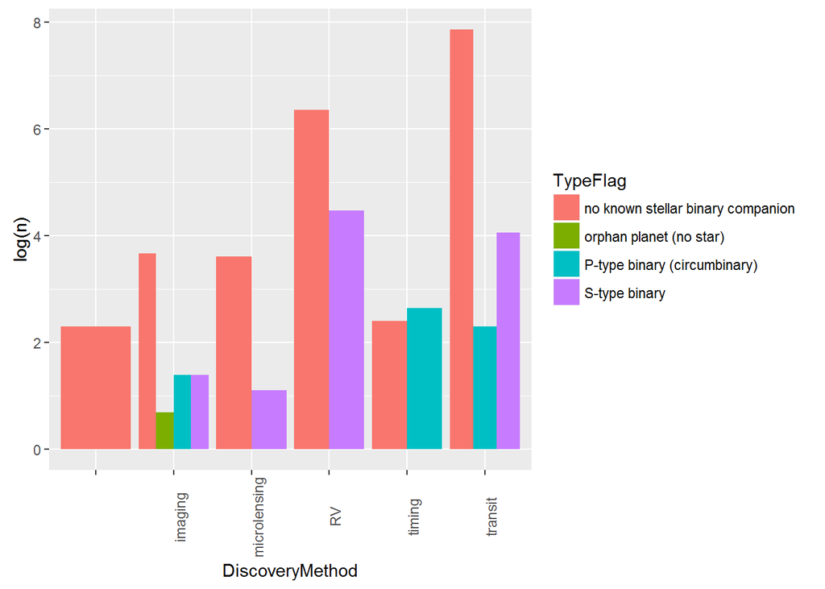

```r
temp <- oec %>% select(TypeFlag,DiscoveryMethod) %>% group_by(TypeFlag,DiscoveryMethod) %>% summarise(n=n())
temp$DiscoveryMethod <- as.factor(temp$DiscoveryMethod)
temp <- subset(temp,n!=0)
ggplot(temp, aes(x=DiscoveryMethod, y=log(n), fill=TypeFlag)) +
geom_bar(position="dodge",stat = 'identity')+theme(axis.text.x = element_text(angle=90, vjust=1))
```

We see that most planets with no known stellar binary companion were discovered by the transit method. The log() scale has been used here so that the heights of the bars are more distinguishable.

## Relationship between star mass and star temperature

We will use the log transformation to ensure that we get readable plot.

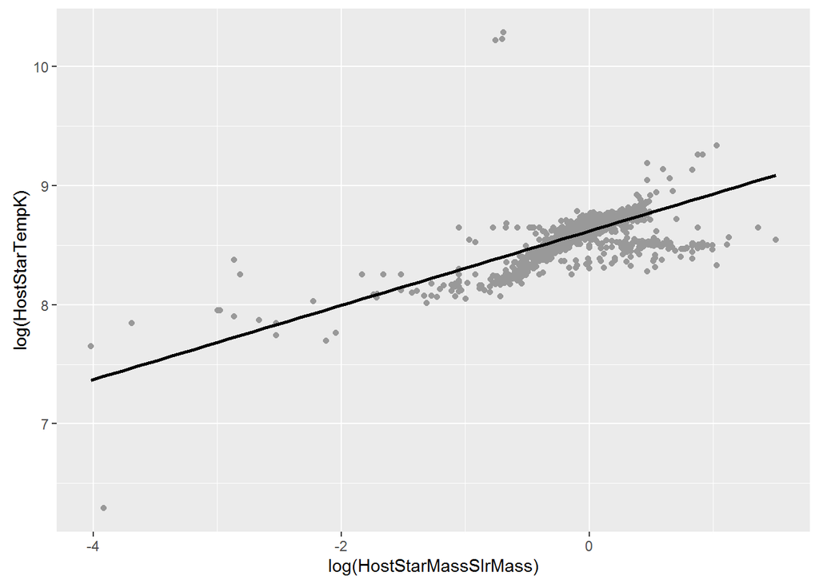

```r
temp <- select(oec,c(HostStarMassSlrMass,HostStarTempK))
temp <- na.omit(temp)
ggplot(temp,aes(x=log(HostStarMassSlrMass),y=log(HostStarTempK)))+geom_point(colour="grey60") +
stat_smooth(method=lm, se=FALSE, colour="black")
```

```r
cor(log(temp$HostStarMassSlrMass),log(temp$HostStarTempK))
```

```
## [1] 0.6645437
```

```r
summary(lm(log(temp$HostStarTempK)~log(temp$HostStarMassSlrMass)))
```

```
##
## Call:
## lm(formula = log(temp$HostStarTempK) ~ log(temp$HostStarMassSlrMass))
##
## Residuals:
##      Min       1Q   Median       3Q      Max
## -1.10732 -0.02521  0.02163  0.05021  1.88282
##
## Coefficients:
##                               Estimate Std. Error t value Pr(>|t|)
## (Intercept)                   8.618646   0.002301 3745.99   <2e-16 ***
## log(temp$HostStarMassSlrMass) 0.311797   0.006221   50.12   <2e-16 ***
## ---
## Signif. codes:  0 '***' 0.001 '**' 0.01 '*' 0.05 '.' 0.1 ' ' 1
##
## Residual standard error: 0.1275 on 3176 degrees of freedom
## Multiple R-squared:  0.4416, Adjusted R-squared:  0.4414
## F-statistic:  2512 on 1 and 3176 DF,  p-value: < 2.2e-16
```

We get a fairly high correlation of 0.66. As the mass of the star increases, the temperature of the star also increases. As per the linear fit, the equation would be $log(Temperature(Kelvin))= 0.312*log(Mass(Solar))+8.619$

## Eccentricity, Period and Mass

Eccentricity of 0 denotes a perfect circle. A value lies between 0 and 1. Does eccentricity affect the planet’s period of revolution? We will check this out by removing outliers.

```r
temp <- oec %>% select(Eccentricity,PeriodDays,PlanetaryMassJpt)
qnt <- quantile(temp$PeriodDays, probs=c(.25, .75), na.rm = T)
H <- 1.5 * IQR(temp$PeriodDays, na.rm =T)

temp$PeriodDays <- ifelse(temp$PeriodDays<(qnt[1]-H),NA,temp$PeriodDays)
temp$PeriodDays <- ifelse(temp$PeriodDays>(qnt[2]+H),NA,temp$PeriodDays)
temp <- na.omit(temp)
ggplotly(ggplot(temp, aes(x=(PeriodDays), y=(Eccentricity))) + geom_point(colour="grey60") +stat_smooth(method=loess, se=FALSE, colour="black"))
```

[interactive chart not shown]

```r
cor(temp$Eccentricity,temp$PeriodDays)
```

```
## [1] 0.3813954
```

We see a small correlation between period of the planet and its eccentricity.This suggests that there is not a linear relationship between these two variables.

**Is there a relationship between eccentricity and mass of the planet?**

```r
temp <- oec %>% select(Eccentricity,PeriodDays,PlanetaryMassJpt)

qnt <- quantile(temp$PlanetaryMassJpt, probs=c(.25, .75), na.rm = T)
H <- 1.5 * IQR(temp$PlanetaryMassJpt, na.rm =T)
temp$PlanetaryMassJpt <- ifelse(temp$PlanetaryMassJpt<(qnt[1]-H),NA,temp$PlanetaryMassJpt)
temp$PlanetaryMassJpt <- ifelse(temp$PlanetaryMassJpt>(qnt[2]+H),NA,temp$PlanetaryMassJpt)
temp <- na.omit(temp)
ggplotly(ggplot(temp, aes(x=PlanetaryMassJpt, y=Eccentricity)) + geom_point(colour="grey60") +stat_smooth(method=loess, se=FALSE, colour="black"))
```

[interactive chart not shown]

```r
cor(temp$Eccentricity,temp$PlanetaryMassJpt)
```

```
## [1] 0.2371403
```

There is a low correlation here as well.

**What about mass of planet and period?**

```r
temp <- oec %>% select(Eccentricity,PeriodDays,PlanetaryMassJpt)

qnt <- quantile(temp$PlanetaryMassJpt, probs=c(.25, .75), na.rm = T)
H <- 1.5 * IQR(temp$PlanetaryMassJpt, na.rm =T)
temp$PlanetaryMassJpt <- ifelse(temp$PlanetaryMassJpt<(qnt[1]-H),NA,temp$PlanetaryMassJpt)
temp$PlanetaryMassJpt <- ifelse(temp$PlanetaryMassJpt>(qnt[2]+H),NA,temp$PlanetaryMassJpt)

qnt <- quantile(temp$PeriodDays, probs=c(.25, .75), na.rm = T)
H <- 1.5 * IQR(temp$PeriodDays, na.rm =T)
temp$PeriodDays <- ifelse(temp$PeriodDays<(qnt[1]-H),NA,temp$PeriodDays)
temp$PeriodDays <- ifelse(temp$PeriodDays>(qnt[2]+H),NA,temp$PeriodDays)

temp <- na.omit(temp)

ggplotly(ggplot(temp, aes(x=PlanetaryMassJpt, y=PeriodDays)) + geom_point(colour="grey60") +stat_smooth(method=loess, se=FALSE, colour="black"))
```

[interactive chart not shown]

```r
cor(temp$PeriodDays,temp$PlanetaryMassJpt)
```

```
## [1] -0.08146423
```

## Relationship between Host star’s temperature and the planets’ equilibrium temperature

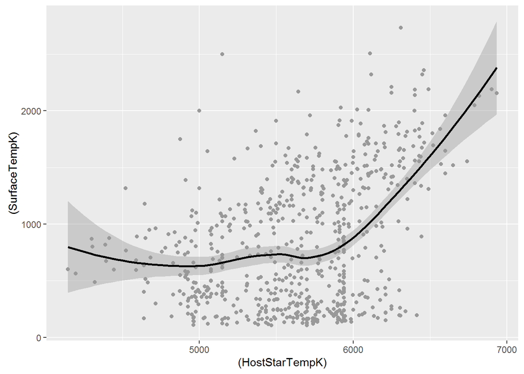

```r
temp<- na.omit(oec %>% select(HostStarTempK,SurfaceTempK))
qnt <- quantile(temp$HostStarTempK, probs=c(.25, .75), na.rm = T)
H <- 1.5 * IQR(temp$HostStarTempK, na.rm =T)
temp$HostStarTempK <- ifelse(temp$HostStarTempK<(qnt[1]-H),NA,temp$HostStarTempK)
temp$HostStarTempK <- ifelse(temp$HostStarTempK>(qnt[2]+H),NA,temp$HostStarTempK)

qnt <- quantile(temp$SurfaceTempK, probs=c(.25, .75), na.rm = T)
H <- 1.5 * IQR(temp$SurfaceTempK, na.rm =T)
temp$SurfaceTempK <- ifelse(temp$SurfaceTempK<(qnt[1]-H),NA,temp$SurfaceTempK)
temp$SurfaceTempK <- ifelse(temp$SurfaceTempK>(qnt[2]+H),NA,temp$SurfaceTempK)
temp <- na.omit(temp)

ggplot(temp, aes(x=(HostStarTempK), y=(SurfaceTempK))) + geom_point(colour="grey60") +
stat_smooth(method=loess, se=T, colour="black")
```

```r
cor(temp$HostStarTempK,temp$SurfaceTempK)
```

```
## [1] 0.3607405
```

There seems to be little correlation. The relationship is certainly non linear.

## Metallicity

It is the property that evaluates the proportion of the material of a celestial object that is an element other than hydrogen or helium.

**How are they distributed?**

```r
h <- ggplot((oec), aes(x=HostStarMetallicity))
ggplotly(h + geom_histogram(binwidth=0.1, fill="white", colour="black"))
```

[interactive chart not shown]

```r
summary(oec$HostStarMetallicity)
```

```
##    Min. 1st Qu.  Median    Mean 3rd Qu.    Max.    NA's
## -2.0900 -0.0500  0.0200  0.0146  0.1000  0.5600    1046
```

We see that the range of metallicity is from -2.09 to 0.56. Negative metallicity means having metallicity lower than that of the Sun.

We will analyze this further.

**Does the metallicity of a star related to its temperature?**

It this different for different radii? Let’s divide this dataset into three parts so that we can visualize it more clearly

Radii between 0 -10

Radii between 10 and 50

Radii lesser than 2

```r
temp <- oec %>% select(HostStarTempK,HostStarMetallicity,HostStarRadiusSlrRad)
temp <- na.omit(temp)
temp_1 <- filter(temp,HostStarRadiusSlrRad>10)
temp_2 <- filter(temp,HostStarRadiusSlrRad<10)
temp_3 <- filter(temp,HostStarRadiusSlrRad<2)
plot_ly(temp_1, x = HostStarRadiusSlrRad, y = HostStarMetallicity ,color = HostStarTempK , mode ="markers",text=paste('Temperature', HostStarTempK))
```

[interactive chart not shown]

```r
plot_ly(temp_2, x = HostStarRadiusSlrRad, y = HostStarMetallicity ,color = HostStarTempK , mode ="markers",text=paste('Temperature', HostStarTempK))
```

[interactive chart not shown]

```r
plot_ly(temp_3, x = HostStarRadiusSlrRad, y = HostStarMetallicity ,color = HostStarTempK , mode ="markers",text=paste('Temperature', HostStarTempK))
```

[interactive chart not shown]

From the above plots we see that hotter stars tend to have radii ranging between 0.8 to 2 Solar Radius. The cooler stars tend to fall outside this range. The metallicity of stars seem to be independent of its temperature and radii.

## Relationship between SemiMajor Axis and Period

We will apply the log transformation to the data

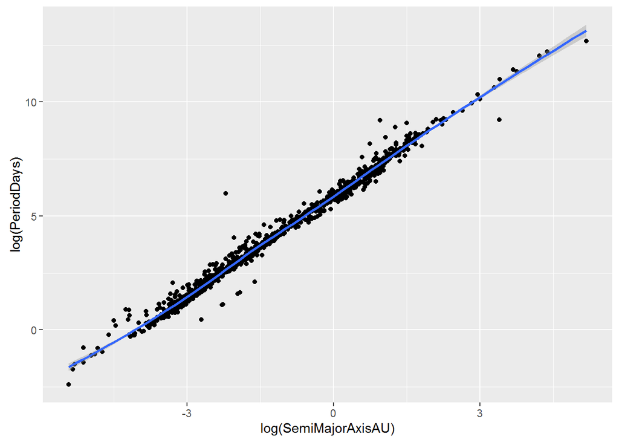

```r
temp <- select(oec,c(SemiMajorAxisAU,PeriodDays))
temp <- na.omit(temp)
ggplot(temp, aes(x=log(SemiMajorAxisAU), y=log(PeriodDays)))+geom_point()+stat_smooth(method=loess, level=0.95)
```

```r
summary(lm(log(temp$PeriodDays)~log(temp$SemiMajorAxisAU)))
```

```
##
## Call:
## lm(formula = log(temp$PeriodDays) ~ log(temp$SemiMajorAxisAU))
##
## Residuals:
##     Min      1Q  Median      3Q     Max
## -1.6491 -0.1203 -0.0199  0.0784  3.3477
##
## Coefficients:
##                           Estimate Std. Error t value Pr(>|t|)
## (Intercept)               5.868461   0.009579   612.6   <2e-16 ***
## log(temp$SemiMajorAxisAU) 1.467421   0.004364   336.3   <2e-16 ***
## ---
## Signif. codes:  0 '***' 0.001 '**' 0.01 '*' 0.05 '.' 0.1 ' ' 1
##
## Residual standard error: 0.2674 on 1234 degrees of freedom
## Multiple R-squared:  0.9892, Adjusted R-squared:  0.9892
## F-statistic: 1.131e+05 on 1 and 1234 DF,  p-value: < 2.2e-16
```

## Relationship between Radius and Mass of planet

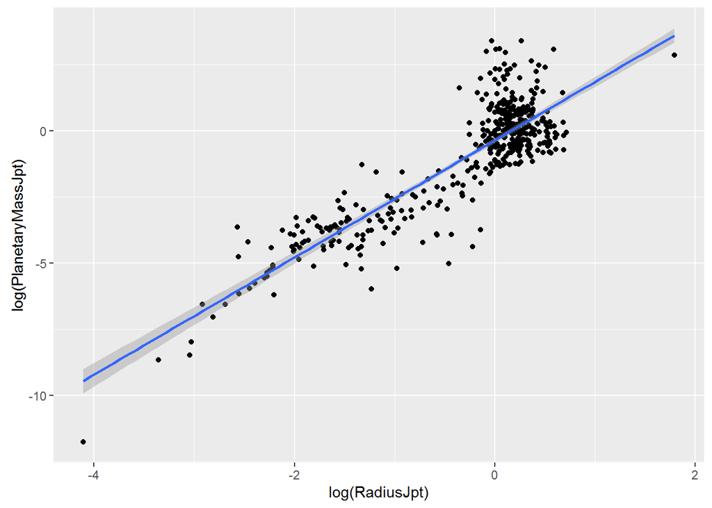

```r
temp <- select(oec,c(RadiusJpt,PlanetaryMassJpt))
temp <- na.omit(temp)
ggplot(temp, aes(x=log(RadiusJpt), y=log(PlanetaryMassJpt)))+geom_point()+stat_smooth(method=lm, level=0.95)
```

```r
summary(lm(log(temp$PlanetaryMassJpt)~log(temp$RadiusJpt)))
```

```
##
## Call:
## lm(formula = log(temp$PlanetaryMassJpt) ~ log(temp$RadiusJpt))
##
## Residuals:
##     Min      1Q  Median      3Q     Max
## -3.6470 -0.7129 -0.1002  0.5484  3.8299
##
## Coefficients:
##                     Estimate Std. Error t value Pr(>|t|)
## (Intercept)         -0.36131    0.05543  -6.518 1.98e-10 ***
## log(temp$RadiusJpt)  2.21399    0.05997  36.919  < 2e-16 ***
## ---
## Signif. codes:  0 '***' 0.001 '**' 0.01 '*' 0.05 '.' 0.1 ' ' 1
##
## Residual standard error: 1.093 on 433 degrees of freedom
## Multiple R-squared:  0.7589, Adjusted R-squared:  0.7584
## F-statistic:  1363 on 1 and 433 DF,  p-value: < 2.2e-16
```

```r
cor(log(temp$PlanetaryMassJpt),log(temp$RadiusJpt))
```

```
## [1] 0.8711545
```

The log transformed correlation is 0.87. The linear model to predict Planetary Mass from Radius would be $log(PlanetaryMass(Jupiter Units))=2.21*log(Radius(Jupiter Radii))-0.361$